# Fama–French-faktoriaineiston lataaminen R:llä

Petri Rautiainen

2026-09-08

## 1. Miksi faktoriaineisto kiinnostaa sijoitusanalyytikkoa?

Sijoituksen toteutunut tuotto ei yksin kerro, millaisten riskien kantamisesta tuotto on syntynyt. Salkku voi esimerkiksi näyttää menestyneen hyvin, vaikka tulos selittyisi suurelta osin yleisellä markkinakehityksellä, pienten yritysten painottamisella tai arvo-osakkeisiin kohdistuneella sijoitustyylillä.

Fama–French-faktoriaineisto tarjoaa standardoidun lähtökohdan tällaisten systemaattisten tuottolähteiden tarkasteluun. Faktoreiden avulla voidaan myöhemmin tutkia esimerkiksi sitä, kuinka paljon rahaston tai sijoitusstrategian tuotoista liittyy markkinariskiin ja kuinka paljon muihin tunnistettuihin sijoitustyyleihin.

Tämän artikkelin tavoitteena ei ole vielä arvioida faktoreiden historiallista kannattavuutta tai rakentaa faktorisijoitusstrategiaa. Ensin tarvitaan luotettava ja toistettava tapa:

1. hakea alkuperäinen faktoriaineisto
2. tunnistaa oikea taulu ja havaintofrekvenssi
3. muuntaa päivämäärät ja tuotot analyysiin sopivaan muotoon
4. validoida lopputulos ennen sen käyttämistä
5. tarkastella aineiston historiallista käyttäytymistä kuvioiden avulla

Hyvin rakennettu datanlatausprosessi voidaan myöhemmin yhdistää esimerkiksi rahasto-, salkku- tai indeksituottoihin.

## 2. Mitä Fama–French-faktorit kuvaavat?

Kuukausittainen Fama–Frenchin kolmen faktorin aineisto sisältää seuraavat muuttujat:

- **Mkt-RF** kuvaa markkinasalkun tuottoa, josta on vähennetty riskitön korko. Kyse on siis markkinan ylituotosta suhteessa riskittömään korkoon.
- **SMB**, eli *Small Minus Big*, kuvaa pienten ja suurten yritysten osakkeiden tuottoeroa.
- **HML**, eli *High Minus Low*, kuvaa korkean ja matalan book-to-market-luvun osakkeiden tuottoeroa. Sitä käytetään tyypillisesti arvo- ja kasvuosakkeiden välisen tuottoeron kuvaamiseen.
- **RF** kuvaa aineistossa käytettyä riskitöntä korkoa.

Fama–Frenchin viiden faktorin aineistossa ovat lisäksi:

- **RMW**, eli *Robust Minus Weak*, joka liittyy yritysten kannattavuuteen
- **CMA**, eli *Conservative Minus Aggressive*, joka liittyy yritysten investointikäyttäytymiseen

Tässä artikkelissa käytetään kuukausittaista kolmen faktorin aineistoa. Se muodostaa yksinkertaisen lähtökohdan datan käsittelylle ja myöhemmin toteutettavalle faktorianalyysille.

Faktorit eivät ole tavallisia osakeindeksejä. SMB ja HML ovat laskennallisia long-short-sarjoja, joissa yhden osakeryhmän tuotoista vähennetään toisen osakeryhmän tuotot. Negatiivinen faktorituotto ei siten tarkoita, että kaikki faktoriin liittyvät osakkeet olisivat laskeneet.

## 3. Aineiston lähde

Aineiston virallinen lähde on [Kenneth French Data Library](https://mba.tuck.dartmouth.edu/pages/faculty/ken.french/data_library.html).

Data Librarysta löytyy useita toisistaan poikkeavia faktori- ja portfoliotaulukoita. Aineistoja on saatavilla esimerkiksi:

- kuukausi-, viikko- ja päiväfrekvenssillä
- kolmen ja viiden faktorin malleille
- eri markkina-alueille
- erilaisille valmiiksi muodostetuille portfolioille

Ladattavan tiedoston nimi ei yksin riitä aineiston sisällön varmistamiseen. Ennen analyysia pitää tarkistaa ainakin:

- käytetty markkina-alue
- havaintofrekvenssi
- tarkastelujakso
- tuottojen yksikkö
- tiedoston sisältämät erilliset taulut
- faktoreiden määrittely
- lähdeaineiston dokumentaatio

Tämä on erityisen tärkeää silloin, kun faktoriaineisto yhdistetään ulkopuoliseen tuottosarjaan. Kuukausi- ja päivätuottoja ei voi yhdistää sellaisenaan, ja myös päivämäärien kohdistamisen pitää olla johdonmukaista.

## Aineiston tuotantotapa voi muuttua

Kenneth French Data Library kertoo Yhdysvaltain tutkimustuottojen tausta-aineiston käsittelyn muuttuneen CRSP:n siirryttyä uuteen tiedostoformaattiin. Pitkiä historiallisia sarjoja tulkittaessa myös aineiston tuotantotavan muutokset pitää huomioida.

Ajantasaiset kuvaukset löytyvät aina Data Librarysta.

## 4. Kaksi tapaa ladata aineisto R:ään

Fama–French-aineiston voi hakea R:ään ainakin kahdella tavalla:

1. `frenchdata`-paketin avulla
2. lataamalla alkuperäisen ZIP-tiedoston suoraan Kenneth French Data Librarysta

`frenchdata`-paketti helpottaa aineistojen löytämistä ja tiedoston sisältämien taulujen käsittelyä. Suora lataus puolestaan antaa enemmän kontrollia siihen, miten alkuperäinen tiedosto luetaan ja muunnetaan.

Kummassakin tapauksessa lopputulos pitää validoida. Erityistä huomiota vaativat:

- kuukausi- ja vuositaulujen erottaminen
- `YYYYMM`-muotoiset päivämäärät
- prosenttimuotoiset tuotot
- mahdolliset otsikko- ja seliterivit
- puuttuvat tai virheellisesti tulkitut havainnot

Tässä artikkelissa varsinainen analyysiaineisto ladataan `frenchdata`-paketilla. Suora ZIP-lataus esitetään vaihtoehtoisena menetelmänä, mutta sitä ei suoriteta artikkelin renderöinnin yhteydessä.

## 5. Vaihtoehto A: lataaminen frenchdata-paketilla

`frenchdata`-paketti tarjoaa dokumentoidun rajapinnan Kenneth French Data Libraryn aineistoihin.

Paketti voidaan tarvittaessa asentaa seuraavasti:

```r
install.packages("frenchdata")
```

Asennuskomentoa ei sisällytetä varsinaiseen analyysiskriptiin. Artikkelin alussa oleva asetuskoodi tarkistaa paketin saatavuuden ja keskeyttää renderöinnin ymmärrettävällä virheilmoituksella, jos paketti puuttuu.

Ladataan Fama–Frenchin kuukausittainen kolmen faktorin aineisto:

```r
factors <- frenchdata::download_french_data(
  "Fama/French 3 Factors"
)
```

Ladattu objekti sisältää erillisiä tauluja eli osajoukkoja. Tarkistetaan niiden nimet:

```r
factors$subsets |>
  dplyr::select(name)
```

```
## # A tibble: 2 × 1
##   name
##   <chr>
## 1 ""
## 2 "Annual Factors: January-December"
```

Kuukausittainen taulu on paketin dokumentoidussa esimerkkirakenteessa ensimmäinen, nimeämätön osajoukko. Vuosittainen taulu on merkitty erikseen.

Valitaan kuukausittainen taulu, mutta tarkistetaan ensin, että osajoukkoja todella löytyy:

```r
if (
  is.null(factors$subsets) ||
  nrow(factors$subsets) == 0
) {
  stop("Ladattu objekti ei sisältänyt odotettuja osajoukkoja.")
}

subset_names <- factors$subsets$name
monthly_index <- which(subset_names == "")[1]

if (
  length(monthly_index) == 0 ||
  is.na(monthly_index)
) {
  stop("Kuukausittaista faktoriaineistoa ei pystytty tunnistamaan.")
}

factor_data_raw <- factors$subsets$data[[monthly_index]]
```

Taulun valinta ei vielä riitä. Seuraavaksi tarkistetaan, vastaako sen rakenne odotuksia.

## 6. Vaihtoehto B: ZIP-tiedoston lataaminen suoraan

Aineiston voi ladata myös suoraan Data Librarysta ZIP-tiedostona.

Seuraava koodi on tarkoitettu vaihtoehtoisen lataustavan havainnollistamiseen. Sitä ei suoriteta tämän artikkelin renderöinnin yhteydessä.

```r
zip_url <- paste0(
  "https://mba.tuck.dartmouth.edu/pages/faculty/ken.french/ftp/",
  "F-F_Research_Data_Factors_CSV.zip"
)

zip_path <- tempfile(fileext = ".zip")
extract_dir <- tempfile(pattern = "fama_french_")

dir.create(extract_dir)

download.file(
  url = zip_url,
  destfile = zip_path,
  mode = "wb",
  quiet = TRUE
)

unzip(
  zipfile = zip_path,
  exdir = extract_dir
)

csv_files <- list.files(
  path = extract_dir,
  pattern = "\\.csv$",
  full.names = TRUE,
  ignore.case = TRUE
)

if (length(csv_files) != 1) {
  stop(
    paste(
      "ZIP-tiedostosta odotettiin löytyvän yksi CSV-tiedosto.",
      "Löydettyjen tiedostojen määrä:",
      length(csv_files)
    )
  )
}

csv_file <- csv_files[[1]]
```

CSV-tiedostoa ei kannata lukea olettaen, että koko tiedosto olisi yksi suorakulmainen datataulu. Tiedosto voi sisältää esimerkiksi:

- aineiston kuvaustekstiä
- kuukausittaisen taulun
- tyhjiä rivejä
- vuosittaisen taulun
- muita selitteitä

Rakennetta voidaan ensin tarkastella riveittäin:

```r
raw_lines <- readLines(
  con = csv_file,
  encoding = "UTF-8",
  warn = FALSE
)

head(raw_lines, 20)
tail(raw_lines, 20)
```

Kuukausittaisen taulun tunnistus kannattaa perustaa rivien sisältöön, ei kiinteisiin rivinumeroihin. Lähdetiedoston rakenne voi muuttua.

Väliaikaiset tiedostot voidaan poistaa käsittelyn jälkeen:

```r
unlink(zip_path)
unlink(extract_dir, recursive = TRUE)
```

## 7. Aineiston rakenteen tarkistaminen

Ennen sarakkeiden nimeämistä ja muuntamista varmistetaan, että valittu taulu sisältää odotetun aineiston.

```r
str(factor_data_raw)
```

```
## spc_tbl_ [1,201 × 5] (S3: spec_tbl_df/tbl_df/tbl/data.frame)
##  $ date  : num [1:1201] 192607 192608 192609 192610 192611 ...
##  $ Mkt-RF: num [1:1201] 2.89 2.64 0.38 -3.27 2.54 2.62 -0.05 4.17 0.14 0.47 ...
##  $ SMB   : num [1:1201] -2.42 -1.44 -1.36 -0.18 -0.17 -0.06 -0.47 -0.23 -2.01 0.54 ...
##  $ HML   : num [1:1201] -2.75 4.13 0.05 0.78 -0.48 0.1 4.76 3.04 -2.32 0.62 ...
##  $ RF    : num [1:1201] 0.22 0.25 0.23 0.32 0.31 0.28 0.25 0.26 0.3 0.25 ...
##  - attr(*, "spec")=
##   .. cols(
##   ..   ...1 = col_double(),
##   ..   `Mkt-RF` = col_double(),
##   ..   SMB = col_double(),
##   ..   HML = col_double(),
##   ..   RF = col_double()
##   .. )
##  - attr(*, "problems")=<externalptr>
```

Näytetään vain aineiston ensimmäiset ja viimeiset havainnot:

```r
dplyr::bind_rows(
  utils::head(factor_data_raw, 6),
  utils::tail(factor_data_raw, 6)
)
```

```
## # A tibble: 12 × 5
##      date `Mkt-RF`   SMB   HML    RF
##     <dbl>    <dbl> <dbl> <dbl> <dbl>
##  1 192607     2.89 -2.42 -2.75  0.22
##  2 192608     2.64 -1.44  4.13  0.25
##  3 192609     0.38 -1.36  0.05  0.23
##  4 192610    -3.27 -0.18  0.78  0.32
##  5 192611     2.54 -0.17 -0.48  0.31
##  6 192612     2.62 -0.06  0.1   0.28
##  7 202602    -1.17  0.16  2.8   0.28
##  8 202603    -5.18  0.44  3.29  0.29
##  9 202604     9.95  0.19 -1.37  0.29
## 10 202605     4.91 -1.59 -2.31  0.31
## 11 202606    -1.07  3.39  3.58  0.29
## 12 202607    -0.6  -1.96  2.11  0.33
```

Tarkistettavia asioita ovat esimerkiksi:

- onko ensimmäinen sarake kuukausi muodossa `YYYYMM`
- löytyvätkö Mkt-RF-, SMB-, HML- ja RF-sarakkeet
- ovatko faktorisarakkeet numeerisia
- sisältääkö taulu vuosihavaintoja kuukausihavaintojen lisäksi
- onko aineistossa tyhjiä tai selvästi virheellisiä rivejä

Kuukausihavainnon tunnisteen pitäisi sisältää kuusi numeroa. Käytetään tätä yhtenä rakenne-ehtona:

```r
date_code <- trimws(
  as.character(factor_data_raw[[1]])
)

monthly_rows <- grepl(
  "^[0-9]{6}$",
  date_code
)

factor_data_raw <- factor_data_raw[
  monthly_rows,
  ,
  drop = FALSE
]

if (nrow(factor_data_raw) == 0) {
  stop("Aineistosta ei löytynyt YYYYMM-muotoisia kuukausihavaintoja.")
}
```

Tämä rajaa aineistoon vain rivit, joiden ensimmäinen kenttä vastaa `YYYYMM`-rakennetta. Rajaus ei kuitenkaan korvaa lähdetiedoston dokumentaation tarkistamista.

## 8. Päivämäärien ja tuottojen muuntaminen

Taulusta pitää löytyä päivämääräkentän lisäksi neljä faktorikenttää.

```r
required_column_count <- 5

if (ncol(factor_data_raw) < required_column_count) {
  stop(
    paste(
      "Aineistossa ei ole odotettua määrää sarakkeita.",
      "Odotettiin vähintään:",
      required_column_count,
      "Löydettiin:",
      ncol(factor_data_raw)
    )
  )
}
```

Valitaan tarvittavat sarakkeet ja standardoidaan niiden nimet:

```r
factor_data <- factor_data_raw[
  ,
  seq_len(required_column_count)
]

names(factor_data) <- c(
  "date_code",
  "market_excess",
  "size",
  "value",
  "risk_free"
)
```

Faktorisarakkeet muunnetaan numeerisiksi:

```r
factor_columns <- c(
  "market_excess",
  "size",
  "value",
  "risk_free"
)

factor_data[factor_columns] <- lapply(
  factor_data[factor_columns],
  function(x) {
    as.numeric(trimws(as.character(x)))
  }
)
```

Kenneth French Data Library voi käyttää puuttuvien havaintojen merkintöinä esimerkiksi arvoja `-99.99` ja `-999`. Ne pitää tunnistaa ennen prosenttien muuntamista desimaaleiksi.

```r
missing_value_codes <- c(
  -99.99,
  -999
)

contains_missing_codes <- vapply(
  factor_data[factor_columns],
  function(x) {
    any(
      x %in% missing_value_codes,
      na.rm = TRUE
    )
  },
  logical(1)
)

if (any(contains_missing_codes)) {
  affected_columns <- names(
    contains_missing_codes
  )[contains_missing_codes]

  stop(
    paste(
      "Aineistossa havaittiin puuttuvan tiedon tunnuksia sarakkeissa:",
      paste(affected_columns, collapse = ", ")
    )
  )
}
```

Muunnetaan `YYYYMM`-koodit R:n `Date`-luokkaan lisäämällä kuukauden ensimmäinen päivä:

```r
factor_data$date_code <- trimws(
  as.character(factor_data$date_code)
)

factor_data$date <- as.Date(
  paste0(
    substr(factor_data$date_code, 1, 4),
    "-",
    substr(factor_data$date_code, 5, 6),
    "-01"
  )
)
```

Päivämäärä kuvaa tässä havaintokuukautta. Kuukauden ensimmäisen päivän käyttäminen on tekninen ratkaisu kuukausihavainnon tallentamiseen.

Aineistoa muihin tuottosarjoihin yhdistettäessä pitää käyttää kaikissa aineistoissa samaa kuukausikohdistusta.

Alkuperäiset prosenttimuotoiset tuotot muunnetaan desimaalimuotoon jakamalla ne sadalla:

```r
factor_data[factor_columns] <- lapply(
  factor_data[factor_columns],
  function(x) {
    x / 100
  }
)
```

Esimerkiksi yhden prosentin tuotto tallentuu tämän jälkeen arvona `0.01`.

Muunnos pitää tehdä täsmälleen kerran. Jo desimaalimuodossa olevan aineiston jakaminen uudelleen sadalla vääristäisi tulokset.

## 9. Datan validointitarkistukset

Ennen aineiston käyttämistä ja tallentamista suoritetaan järjestelmälliset tarkistukset.

### Sarakkeet

```r
required_columns <- c(
  "date",
  "market_excess",
  "size",
  "value",
  "risk_free"
)

missing_columns <- setdiff(
  required_columns,
  names(factor_data)
)

if (length(missing_columns) > 0) {
  stop(
    paste(
      "Aineistosta puuttuvat sarakkeet:",
      paste(missing_columns, collapse = ", ")
    )
  )
}
```

### Päivämäärät

```r
if (anyNA(factor_data$date)) {
  stop(
    "Päivämäärissä on puuttuvia tai virheellisiä arvoja."
  )
}

if (anyDuplicated(factor_data$date) > 0) {
  stop(
    "Päivämäärissä on duplikaatteja."
  )
}

if (is.unsorted(factor_data$date, strictly = TRUE)) {
  stop(
    "Päivämäärät eivät ole aidosti nousevassa järjestyksessä."
  )
}
```

### Faktorihavainnot

```r
numeric_checks <- vapply(
  factor_data[factor_columns],
  is.numeric,
  logical(1)
)

if (!all(numeric_checks)) {
  stop(
    "Kaikki faktorisarakkeet eivät ole numeerisia."
  )
}

if (anyNA(factor_data[factor_columns])) {
  stop(
    "Faktorisarakkeissa on puuttuvia arvoja."
  )
}

finite_checks <- vapply(
  factor_data[factor_columns],
  function(x) {
    all(is.finite(x))
  },
  logical(1)
)

if (!all(finite_checks)) {
  stop(
    "Faktorisarakkeissa on ei-äärellisiä arvoja."
  )
}
```

Tarkistusten tarkoituksena ei ole todistaa, että aineisto olisi taloudellisessa mielessä virheetön. Ne osoittavat, että käsitelty data täyttää myöhempää analyysia varten määritellyt tekniset rakennevaatimukset.

### Validoinnin yhteenveto

```r
validation_summary <- data.frame(
  tarkistus = c(
    "Havaintoja",
    "Ensimmäinen kuukausi",
    "Viimeinen kuukausi",
    "Puuttuvia päivämääriä",
    "Duplikaattipäivämääriä",
    "Puuttuvia faktoriarvoja"
  ),
  tulos = c(
    nrow(factor_data),
    format(min(factor_data$date), "%Y-%m"),
    format(max(factor_data$date), "%Y-%m"),
    sum(is.na(factor_data$date)),
    sum(duplicated(factor_data$date)),
    sum(is.na(factor_data[factor_columns]))
  )
)

knitr::kable(
  validation_summary,
  col.names = c(
    "Tarkistus",
    "Tulos"
  )
)
```

| Tarkistus | Tulos |
| --- | --- |
| Havaintoja | 1201 |
| Ensimmäinen kuukausi | 1926-07 |
| Viimeinen kuukausi | 2026-07 |
| Puuttuvia päivämääriä | 0 |
| Duplikaattipäivämääriä | 0 |
| Puuttuvia faktoriarvoja | 0 |

## Yleisimmät käsittelyvirheet

Fama–French-aineiston käsittelyssä pitää varoa erityisesti seuraavia virheitä:

- prosenttien ja desimaalien sekoittaminen
- prosenttien jakaminen sadalla useammin kuin kerran
- kuukausi- ja vuositaulujen yhdistäminen samaan aineistoon
- `YYYYMM`-koodin tulkitseminen tavalliseksi numeeriseksi muuttujaksi
- puuttuvien arvojen tunnusten käsitteleminen oikeina tuottoina
- lähdetiedoston muuttuneen rakenteen käsitteleminen vanhoilla oletuksilla

Lähdetiedoston rakenne ja dokumentaatio pitää tarkistaa aina ennen analyysin suorittamista.

## 10. Kuukausittaiset faktorituotot

Yksittäisten kuukausien tuottojen kuvaaminen näyttää, kuinka paljon faktorien toteutuneet tuotot vaihtelevat ajan kuluessa.

Markkinan ylituotto, kokofaktori ja arvofaktori esitetään omissa paneeleissaan, koska niiden vaihteluvälit voivat poiketa toisistaan.

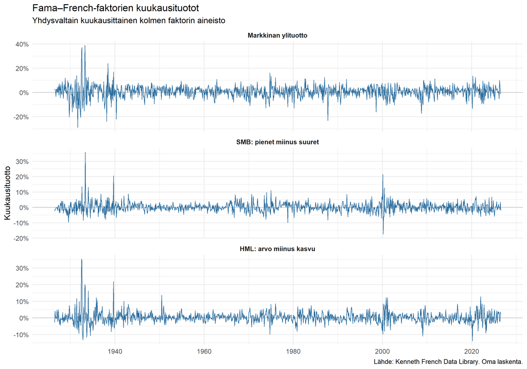

Kuukausittaiset markkina-, koko- ja arvotekijöiden tuotot.

```r
factor_labels <- c(
  market_excess = "Markkinan ylituotto",
  size = "SMB: pienet miinus suuret",
  value = "HML: arvo miinus kasvu"
)

factor_returns_long <- factor_data |>
  dplyr::select(
    date,
    market_excess,
    size,
    value
  ) |>
  tidyr::pivot_longer(
    cols = -date,
    names_to = "factor",
    values_to = "return"
  ) |>
  dplyr::mutate(
    factor = factor(
      factor,
      levels = names(factor_labels),
      labels = unname(factor_labels)
    )
  )

ggplot2::ggplot(
  factor_returns_long,
  ggplot2::aes(
    x = date,
    y = return
  )
) +
  ggplot2::geom_hline(
    yintercept = 0,
    color = "grey70",
    linewidth = 0.3
  ) +
  ggplot2::geom_line(
    color = "#2C6E9F",
    linewidth = 0.35
  ) +
  ggplot2::facet_wrap(
    ~ factor,
    ncol = 1,
    scales = "free_y"
  ) +
  ggplot2::scale_y_continuous(
    labels = scales::label_percent(
      accuracy = 1
    )
  ) +
  ggplot2::labs(
    title = "Fama–French-faktorien kuukausituotot",
    subtitle = "Yhdysvaltain kuukausittainen kolmen faktorin aineisto",
    x = NULL,
    y = "Kuukausituotto",
    caption = paste(
      "Lähde: Kenneth French Data Library.",
      "Oma laskenta."
    )
  ) +
  ggplot2::theme_minimal() +
  ggplot2::theme(
    legend.position = "none",
    strip.text = ggplot2::element_text(
      face = "bold"
    )
  )
```

Kuvio havainnollistaa, että faktorituotot vaihtelevat kuukausittain ja voivat olla sekä positiivisia että negatiivisia.

Esimerkiksi SMB:n negatiivinen arvo tarkoittaa, että suuret yritykset tuottivat kyseisen kuukauden faktorirakenteessa pieniä yrityksiä paremmin. HML:n negatiivinen arvo puolestaan tarkoittaa, että matalan book-to-market-luvun osakkeet tuottivat korkean book-to-market-luvun osakkeita paremmin.

Kuvio ei kuitenkaan yksin kerro, onko jokin faktori ollut pitkällä aikavälillä sijoittajalle palkitseva.

## 11. Markkinan ja faktorien kumulatiivinen kehitys

Kuukausituottojen perusteella voidaan muodostaa laskennallinen kumulatiivinen indeksi. Jokainen sarja alkaa arvosta 100.

Markkinasarjaa varten alkuperäiseen markkinan ylituottoon lisätään riskitön korko:

```
Markkinatuotto = Mkt-RF + RF
```

SMB:n ja HML:n kumulatiiviset sarjat kuvaavat laskennallista toistuvaa sijoitusta faktorien long-short-rakenteeseen. Ne eivät ole tavallisia osakeindeksejä.

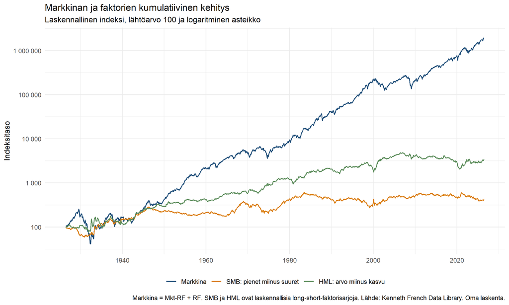

Markkinan ja Fama–French-faktorien laskennallinen kumulatiivinen kehitys, lähtöarvo 100.

```r
cumulative_data <- factor_data |>
  dplyr::arrange(date) |>
  dplyr::transmute(
    date,
    Market = cumprod(
      1 + market_excess + risk_free
    ) * 100,
    SMB = cumprod(
      1 + size
    ) * 100,
    HML = cumprod(
      1 + value
    ) * 100
  ) |>
  tidyr::pivot_longer(
    cols = -date,
    names_to = "series",
    values_to = "index_value"
  ) |>
  dplyr::mutate(
    series = factor(
      series,
      levels = c(
        "Market",
        "SMB",
        "HML"
      ),
      labels = c(
        "Markkina",
        "SMB: pienet miinus suuret",
        "HML: arvo miinus kasvu"
      )
    )
  )

ggplot2::ggplot(
  cumulative_data,
  ggplot2::aes(
    x = date,
    y = index_value,
    color = series
  )
) +
  ggplot2::geom_line(
    linewidth = 0.65
  ) +
  ggplot2::scale_y_log10(
    labels = scales::label_number(
      big.mark = " ",
      decimal.mark = ","
    )
  ) +
  ggplot2::scale_color_manual(
    values = c(
      "Markkina" = "#1F4E79",
      "SMB: pienet miinus suuret" = "#D97904",
      "HML: arvo miinus kasvu" = "#5B8C5A"
    )
  ) +
  ggplot2::labs(
    title = "Markkinan ja faktorien kumulatiivinen kehitys",
    subtitle = paste(
      "Laskennallinen indeksi,",
      "lähtöarvo 100 ja logaritminen asteikko"
    ),
    x = NULL,
    y = "Indeksitaso",
    color = NULL,
    caption = paste(
      "Markkina = Mkt-RF + RF.",
      "SMB ja HML ovat laskennallisia long-short-faktorisarjoja.",
      "Lähde: Kenneth French Data Library. Oma laskenta."
    )
  ) +
  ggplot2::theme_minimal() +
  ggplot2::theme(
    legend.position = "bottom"
  )
```

Logaritminen asteikko helpottaa eri ajankohtien suhteellisten muutosten vertailua. Kuvion tarkoitus ei ole osoittaa, että jokin faktori olisi tulevaisuudessa tuottava, vaan havainnollistaa, kuinka tarkastelutapa muuttuu siirryttäessä kuukausihavainnoista pitkän aikavälin kumulatiiviseen sarjaan.

## Kumulatiivisen faktorisarjan tulkinta

SMB ja HML ovat long-short-faktoreita. Niiden kumulatiivinen kehitys ei vastaa tavallisen osakesalkun tuottoa.

Kuvio ei myöskään huomioi esimerkiksi kaupankäyntikuluja, veroja, rahoituskustannuksia tai sitä, kuinka helposti faktorisalkku olisi käytännössä toteutettavissa.

## 12. Liukuvat 12 kuukauden tuotot

Pitkän aikavälin kumulatiivinen kuva voi peittää alleen pitkiä heikkoja ja vahvoja jaksoja.

Seuraava kuvio laskee jokaiselle kuukaudelle edeltävien 12 kuukauden kumulatiivisen tuoton. Laskenta toteutetaan ilman erillistä liukuvan laskennan pakettia.

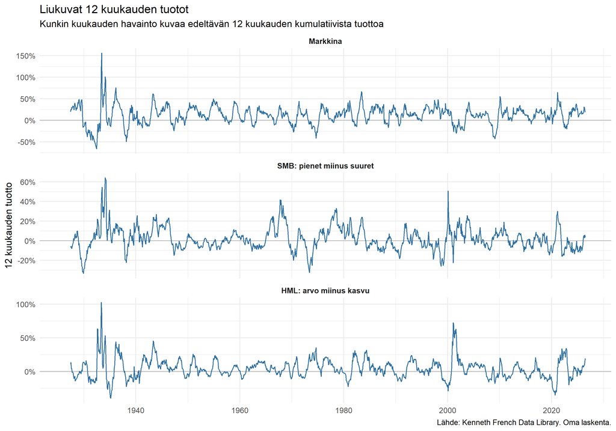

Markkinan ja Fama–French-faktorien liukuvat 12 kuukauden tuotot.

```r
calculate_rolling_return <- function(returns, window = 12) {
  result <- rep(
    NA_real_,
    length(returns)
  )

  if (length(returns) < window) {
    return(result)
  }

  for (index in seq.int(window, length(returns))) {
    window_returns <- returns[
      (index - window + 1):index
    ]

    result[index] <- prod(
      1 + window_returns
    ) - 1
  }

  result
}

rolling_data <- factor_data |>
  dplyr::arrange(date) |>
  dplyr::transmute(
    date,
    market = market_excess + risk_free,
    size,
    value
  ) |>
  dplyr::mutate(
    market = calculate_rolling_return(
      market,
      window = 12
    ),
    size = calculate_rolling_return(
      size,
      window = 12
    ),
    value = calculate_rolling_return(
      value,
      window = 12
    )
  ) |>
  tidyr::pivot_longer(
    cols = -date,
    names_to = "factor",
    values_to = "rolling_return"
  ) |>
  dplyr::mutate(
    factor = factor(
      factor,
      levels = c(
        "market",
        "size",
        "value"
      ),
      labels = c(
        "Markkina",
        "SMB: pienet miinus suuret",
        "HML: arvo miinus kasvu"
      )
    )
  )

ggplot2::ggplot(
  rolling_data,
  ggplot2::aes(
    x = date,
    y = rolling_return
  )
) +
  ggplot2::geom_hline(
    yintercept = 0,
    color = "grey60",
    linewidth = 0.3
  ) +
  ggplot2::geom_line(
    color = "#2C6E9F",
    linewidth = 0.45,
    na.rm = TRUE
  ) +
  ggplot2::facet_wrap(
    ~ factor,
    ncol = 1,
    scales = "free_y"
  ) +
  ggplot2::scale_y_continuous(
    labels = scales::label_percent(
      accuracy = 1
    )
  ) +
  ggplot2::labs(
    title = "Liukuvat 12 kuukauden tuotot",
    subtitle = paste(
      "Kunkin kuukauden havainto kuvaa",
      "edeltävän 12 kuukauden kumulatiivista tuottoa"
    ),
    x = NULL,
    y = "12 kuukauden tuotto",
    caption = paste(
      "Lähde: Kenneth French Data Library.",
      "Oma laskenta."
    )
  ) +
  ggplot2::theme_minimal() +
  ggplot2::theme(
    strip.text = ggplot2::element_text(
      face = "bold"
    )
  )
```

Liukuva tarkastelu tuo esiin sen, että faktorien toteutuneet tuotot voivat vaihdella merkittävästi eri ajanjaksoina.

Historiallinen vaihtelu ei kuitenkaan vielä kerro, johtuuko havaittu tulos pysyvästä riskipreemiosta, arvostustasojen muutoksesta, suhdanteesta, satunnaisvaihtelusta tai aineiston muodostamistavasta.

## 13. Valmis aineisto myöhempää analyysia varten

Validointien jälkeen aineistosta valitaan vain yhdenmukaisesti nimetyt sarakkeet.

```r
processed_data <- factor_data |>
  dplyr::select(
    date,
    market_excess,
    size,
    value,
    risk_free
  )
```

Käsitelty aineisto voidaan tallentaa artikkelin omaan `data/processed`-kansioon.

Polku muodostetaan nykyisen artikkelin hakemistosta. Quarto suorittaa artikkelin koodilohkot oletusarvoisesti dokumentin sijaintiin suhteutetussa ympäristössä, ellei projektin asetuksissa ole määritelty muuta työskentelyhakemistoa.

```r
output_dir <- file.path(
  "data",
  "processed"
)

if (!dir.exists(output_dir)) {
  dir.create(
    output_dir,
    recursive = TRUE
  )
}

output_file <- file.path(
  output_dir,
  "fama_french_3_monthly.csv"
)

utils::write.csv(
  processed_data,
  file = output_file,
  row.names = FALSE,
  fileEncoding = "UTF-8"
)
```

Tallennettu tiedosto sisältää:

- yhdenmukaisesti nimetyt sarakkeet
- `Date`-muotoiset päivämäärät
- desimaalimuotoiset tuotot
- vain kuukausittaiset havainnot
- validointisäännöt läpäisseen aineiston

Tulostiedostoa ei tarvitse välttämättä tallentaa julkiseen GitHub-repositoryyn. Sen sijaan repositoryssa voidaan säilyttää aineiston muodostava R-koodi ja dokumentaatio.

## 14. Rajoitteet ja toistettavuus

Automaattinen latausskripti vähentää manuaalista työtä, mutta se ei poista lähdeaineiston tuntemisen tarvetta.

Kenneth French Data Library voi sisältää aineistokohtaisia huomautuksia, määritelmiä ja rakenteita, joita yleinen käsittelyskripti ei pysty päättelemään. Myös lähdeaineiston tuotantotapa ja historialliset havainnot voivat muuttua tietokantakorjausten yhteydessä.

`frenchdata`-paketti muodostaa lisäksi riippuvuuden analyysin ja ulkoisen R-paketin välille. Paketin toiminta tai latauksen kohteena olevan tiedoston rakenne voi muuttua.

Analyysissä kannattaa dokumentoida ainakin:

- R-versio
- käytetyt paketit ja niiden versiot
- datan hakupäivä
- lähdeosoite
- aineiston nimi
- käytetty markkina-alue
- käytetty havaintofrekvenssi
- alkuperäinen ja lopullinen yksikkö
- kaikki aineistoon tehdyt muunnokset
- käytetyt validointisäännöt

Toistettavuus ei tarkoita vain sitä, että koodi voidaan suorittaa uudelleen. Toisen analyytikon pitäisi myös pystyä ymmärtämään, mitä aineistoa käytettiin, miten se muunnettiin ja millä tarkistuksilla lopputulos hyväksyttiin.

## 15. Mitä seuraavaksi?

Kun faktoriaineiston lataus ja validointi toimivat, seuraava vaihe on yhdistää kuukausittaiset faktorit analysoitavan sijoituksen, rahaston tai indeksin kuukausituottoihin.

Tällöin pitää ratkaista ainakin seuraavat kysymykset:

- käytetäänkö sijoituksesta kokonaistuottoa vai hintatuottoa
- ovatko sijoituksen ja faktoreiden tuotot samassa valuutassa
- vastaavatko havaintokuukaudet toisiaan
- vähennetäänkö sijoituksen tuotosta aineiston riskitön korko
- miten puuttuvat kuukaudet käsitellään
- mikä tarkastelujakso on analyysin kannalta perusteltu
- käytetäänkö kolmen vai viiden faktorin mallia

Vasta näiden tarkistusten jälkeen voidaan siirtyä esimerkiksi faktoriregressioon ja arvioida, millaisia herkkyyksiä analysoitavalla tuottosarjalla on markkina-, koko- ja arvotekijöihin.

## Lähteet

- [Kenneth French Data Library](https://mba.tuck.dartmouth.edu/pages/faculty/ken.french/data_library.html)
- [CRAN: frenchdata-paketin käyttöohje](https://cran.r-project.org/web/packages/frenchdata/vignettes/basic_usage.html)

## Huomautus

Kirjoitus sisältää tekijän omaa analyysia ja menetelmäkuvausta. Se ei edusta työnantajan näkemyksiä eikä ole sijoitussuositus.